# Writeup21: final round of the Gini and heterogeneity sweeps

Kevin Z. Lin (drafted by Claude)

2026-09-23

# 1 Overview

This is the **final round** of the two simulation sweeps that become Figure 4 of the Nature Methods submission of *Resolution of Selection Versus Adaptation in Cellular Evolution*. It ran on 2026-09-23 on the laptop, both axes concurrently, at the design settled by the trailblazing round: 140 datasets per axis (7 levels x 20 replicates), 106.5 minutes for the Gini axis and 116.6 minutes for the AED axis.

Nothing about the simulation changed from the trailblazing `_r2` pass except the replicate count, which rose from 2 to 20. The design itself — the generator, the calibration, the shared 20-PC embedding, the three methods and the metric — is described in `simulation_design_claude.md` and evidenced in `Writeup21_trailblazing-report_claude.html`; this report does not repeat it, and states only what the 20 replicates add.

**The two questions this round existed to answer** (memo Section 9) are both answered, and both resolve in the same direction: what looked erratic on two replicates is not erratic.

A third finding was not on the list and is the most interesting thing in the round: along the AED axis CYFER’s **fate score stays flat while its gene score falls** (Section 3.3).

Every number below is read from the CSVs in `csv/kevin/Writeup21/` (suffix `_final`); the figures in `fig/kevin/Writeup21/` are re-drawn here from the same tables.

# 2 How this round was run

| Setting | Gini axis (4A) | AED axis (4B) |
| --- | --- | --- |
| Levels | t2 Gini 0.3, 0.4, 0.5, 0.6, 0.7, 0.8, 0.9 | mean squared AED 0.1, 0.25, 0.4, 0.55, 0.7, 0.85, 1.0 |
| Held fixed | mean squared AED 0.4 | t2 Gini 0.5 |
| Replicates | 20 | 20 |
| Seeds | `1000 + 100j + r` | `2000 + 100j + r` |
| Wall clock | 106.5 min | 116.6 min |

Shared across both: 100 clones x 10 t1 cells, about 3,000 expected t2 cells with zero-count clones kept, latent dimension 10, `kappa = 1.5`, `tau_delta = 0.6`, `spread_variation = "noncausal"`, a 20-PC embedding shared by all three methods, and t1 cells of extinct clones excluded before CoSPAR. The driver is `sim_final_claude.R`, which takes the axis as its argument and holds these settings once for both.

**The held values both survive the 20 replicates.** AED 0.4 is still the last level at which all three methods do reasonably well (at 0.55 CoSPAR falls to 0.583 and lineage-DE to 0.66), and the held t2 Gini of 0.5 sits comfortably inside CoSPAR’s easy regime (0.698 at 0.5, 0.637 at 0.6). Neither axis needs re-running at a different held value.

Gini axis: calibrated generator parameters per level.

| level | h2 | recentre_steps | s | tau | sigma_w | check_AED |
| --- | --- | --- | --- | --- | --- | --- |
| 0.3 | 0.830 | 2 | 0.367 | 0.335 | 0.151 | 0.426 |
| 0.4 | 0.675 | 1 | 0.558 | 0.458 | 0.318 | 0.420 |
| 0.5 | 0.632 | 1 | 0.763 | 0.607 | 0.462 | 0.408 |
| 0.6 | 0.600 | 0 | 0.965 | 0.747 | 0.610 | 0.401 |
| 0.7 | 0.600 | 0 | 1.360 | 1.050 | 0.857 | 0.391 |
| 0.8 | 0.600 | 0 | 1.580 | 1.230 | 1.000 | 0.394 |
| 0.9 | 0.600 | 0 | 2.060 | 1.590 | 1.300 | 0.406 |

AED axis: calibrated generator parameters per level.

| level | h2 | recentre_steps | s | tau | sigma_w | check_AED |
| --- | --- | --- | --- | --- | --- | --- |
| 0.10 | 1.000 | 3 | 0.619 | 0.619 | 0.000 | 0.130 |
| 0.25 | 0.832 | 1 | 0.652 | 0.595 | 0.267 | 0.267 |
| 0.40 | 0.652 | 1 | 0.804 | 0.649 | 0.474 | 0.405 |
| 0.55 | 0.450 | 0 | 0.847 | 0.568 | 0.628 | 0.572 |
| 0.70 | 0.300 | 0 | 0.991 | 0.543 | 0.829 | 0.706 |
| 0.85 | 0.106 | 1 | 1.160 | 0.377 | 1.100 | 0.847 |
| 1.00 | 0.000 | 3 | 1.250 | 0.000 | 1.250 | 0.932 |

# 3 Results

## 3.1 The headline curves

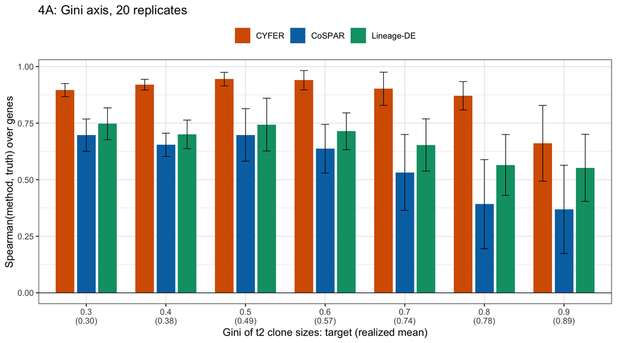

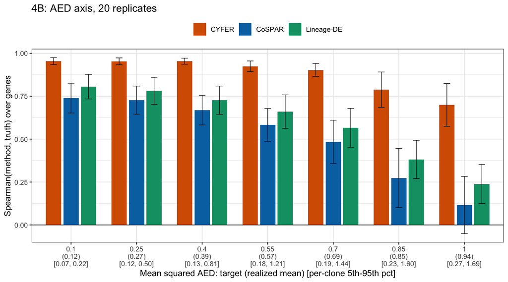

Gini axis: Spearman of each method’s per-gene vector with the truth, mean (SD) over 20 replicates.

| Gini target | CYFER | CoSPAR | Lineage-DE |
| --- | --- | --- | --- |
| 0.3 | 0.896 (0.029) | 0.697 (0.071) | 0.747 (0.070) |
| 0.4 | 0.920 (0.024) | 0.654 (0.051) | 0.701 (0.063) |
| 0.5 | 0.945 (0.030) | 0.698 (0.116) | 0.744 (0.117) |
| 0.6 | 0.940 (0.043) | 0.637 (0.108) | 0.714 (0.081) |
| 0.7 | 0.902 (0.073) | 0.532 (0.168) | 0.653 (0.116) |
| 0.8 | 0.871 (0.062) | 0.392 (0.197) | 0.565 (0.135) |
| 0.9 | 0.661 (0.167) | 0.369 (0.195) | 0.552 (0.148) |

AED axis: Spearman of each method’s per-gene vector with the truth, mean (SD) over 20 replicates.

| AED target | CYFER | CoSPAR | Lineage-DE |
| --- | --- | --- | --- |
| 0.10 | 0.955 (0.020) | 0.739 (0.087) | 0.806 (0.072) |
| 0.25 | 0.953 (0.020) | 0.727 (0.082) | 0.781 (0.079) |
| 0.40 | 0.954 (0.018) | 0.669 (0.086) | 0.727 (0.082) |
| 0.55 | 0.924 (0.031) | 0.583 (0.096) | 0.660 (0.098) |
| 0.70 | 0.903 (0.038) | 0.484 (0.126) | 0.566 (0.113) |
| 0.85 | 0.788 (0.103) | 0.274 (0.172) | 0.382 (0.112) |
| 1.00 | 0.700 (0.125) | 0.116 (0.167) | 0.239 (0.114) |

The separation is large relative to replicate noise everywhere except the top of the Gini axis. CYFER’s SD is at most 0.073 through Gini 0.8 and at most 0.103 through AED 0.85; the comparators’ SDs grow to 0.17–0.20 at the hard ends, which is itself part of the result — the comparators are not merely worse there, they are unstable.

## 3.2 What twenty replicates changed

Gini axis: trailblazing (2 replicates) against the final round (20 replicates).

| level | CYFER (2 rep) | CYFER (20 rep) | CoSPAR (2 rep) | CoSPAR (20 rep) | Lineage-DE (2 rep) | Lineage-DE (20 rep) |
| --- | --- | --- | --- | --- | --- | --- |
| 0.3 | 0.91 | 0.90 | 0.70 | 0.70 | 0.75 | 0.75 |
| 0.4 | 0.91 | 0.92 | 0.71 | 0.65 | 0.75 | 0.70 |
| 0.5 | 0.92 | 0.94 | 0.68 | 0.70 | 0.76 | 0.74 |
| 0.6 | 0.93 | 0.94 | 0.70 | 0.64 | 0.78 | 0.71 |
| 0.7 | 0.92 | 0.90 | 0.27 | 0.53 | 0.48 | 0.65 |
| 0.8 | 0.90 | 0.87 | 0.62 | 0.39 | 0.67 | 0.56 |
| 0.9 | 0.52 | 0.66 | 0.31 | 0.37 | 0.56 | 0.55 |

AED axis: trailblazing (2 replicates) against the final round (20 replicates).

| level | CYFER (2 rep) | CYFER (20 rep) | CoSPAR (2 rep) | CoSPAR (20 rep) | Lineage-DE (2 rep) | Lineage-DE (20 rep) |
| --- | --- | --- | --- | --- | --- | --- |
| 0.10 | 0.95 | 0.95 | 0.69 | 0.74 | 0.75 | 0.81 |
| 0.25 | 0.97 | 0.95 | 0.76 | 0.73 | 0.84 | 0.78 |
| 0.40 | 0.96 | 0.95 | 0.72 | 0.67 | 0.78 | 0.73 |
| 0.55 | 0.88 | 0.92 | 0.47 | 0.58 | 0.51 | 0.66 |
| 0.70 | 0.93 | 0.90 | 0.35 | 0.48 | 0.56 | 0.57 |
| 0.85 | 0.79 | 0.79 | 0.48 | 0.27 | 0.54 | 0.38 |
| 1.00 | 0.82 | 0.70 | -0.03 | 0.12 | 0.23 | 0.24 |

## 3.3 The fate scores behind the gene calls

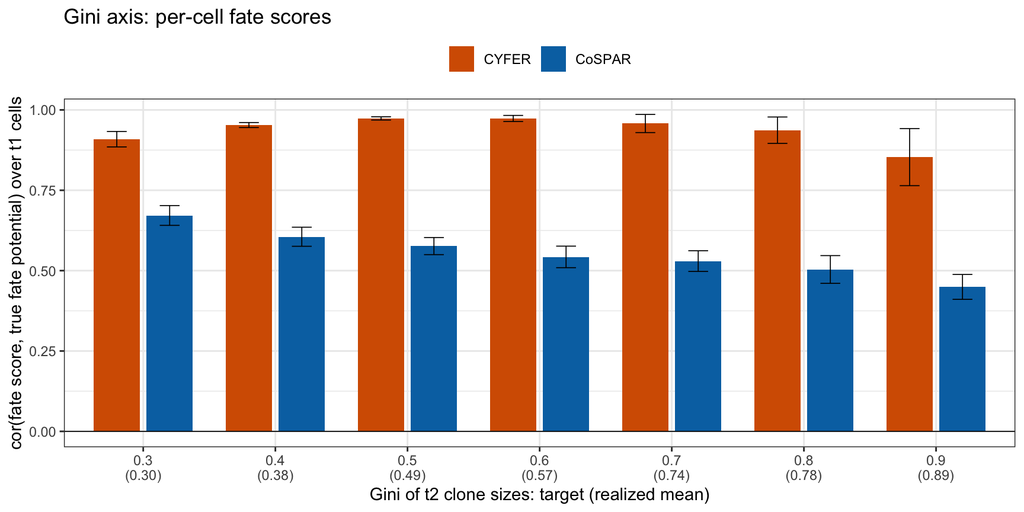

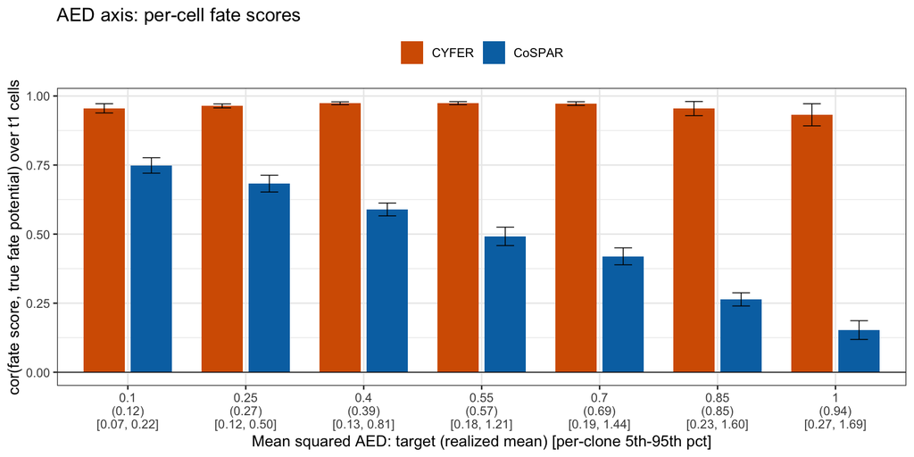

**Lineage-DE has no bars here because it computes no per-cell fate score**: it splits clones into a high and a low group by t2 size and compares the two groups of t1 cells gene by gene, so the only per-cell quantity it touches is the binary group label. Its absence is a property of the method, not a missing computation.

CYFER’s `cell_imputed_score` correlates 0.85–0.97 with `Z_true` at every level of both axes. CoSPAR’s fate bias — over the t1 cells it actually scores, with extinct-clone cells excluded — tops out near 0.75 at the easy ends and decays to 0.449 at Gini 0.9 and 0.153 at AED 1.0.

**The finding worth the paper is in the AED panel.** CYFER’s fate score is essentially flat along that axis — 0.955 at AED 0.1 and 0.932 at AED 1.0, never dipping below 0.93 — while its gene-level score over the same datasets falls from 0.955 to 0.7. Within-clone heterogeneity degrades **what genes can be read off the fate potential, not the fate potential itself**. CoSPAR shows no such decoupling: its fate score falls in step with its genes (0.75 to 0.15), so this is specific to CYFER rather than a property of the generator at high AED.

The mechanism is the one the metric is built on. The operational truth is the per-gene Spearman of expression with `Z_true` over the t1 cells; as the within-clone spread grows, a clone’s cells scatter in expression while their fate potentials stay tied to the clone, so the same fate potential is paired with increasingly noisy expression and the gene-level signal weakens even though the per-cell fate potential is recovered as well as ever. For the paper this separates two claims that are easy to conflate: CYFER’s per-cell scores are robust to heterogeneity, and *gene discovery* from those scores is not.

## 3.4 Where the top Gini level sits

Gini axis: what the top of the ladder does to the data. Means over 20 replicates.

| Gini target | extinct clones | largest t2 clone | % of t2 in it | t1 cells excluded from CoSPAR |
| --- | --- | --- | --- | --- |
| 0.3 | 0.0 | 97.2 | 3.2 | 0.0 |
| 0.4 | 0.0 | 138.1 | 4.6 | 0.5 |
| 0.5 | 0.6 | 196.9 | 6.6 | 5.5 |
| 0.6 | 1.6 | 326.5 | 10.9 | 16.5 |
| 0.7 | 10.8 | 553.8 | 18.5 | 107.5 |
| 0.8 | 15.7 | 609.5 | 20.2 | 156.5 |
| 0.9 | 34.1 | 1059.0 | 35.1 | 341.5 |

## 3.5 Secondary metrics

Gini axis: Pearson version of the metric, mean (SD).

| Gini target | CYFER | CoSPAR | Lineage-DE |
| --- | --- | --- | --- |
| 0.3 | 0.966 (0.012) | 0.855 (0.039) | 0.887 (0.037) |
| 0.4 | 0.983 (0.005) | 0.847 (0.034) | 0.884 (0.032) |
| 0.5 | 0.990 (0.004) | 0.869 (0.030) | 0.900 (0.027) |
| 0.6 | 0.990 (0.006) | 0.821 (0.034) | 0.881 (0.026) |
| 0.7 | 0.985 (0.010) | 0.749 (0.061) | 0.864 (0.032) |
| 0.8 | 0.975 (0.018) | 0.706 (0.130) | 0.848 (0.061) |
| 0.9 | 0.908 (0.073) | 0.526 (0.125) | 0.781 (0.061) |

AED axis: Pearson version of the metric, mean (SD).

| AED target | CYFER | CoSPAR | Lineage-DE |
| --- | --- | --- | --- |
| 0.10 | 0.988 (0.005) | 0.901 (0.026) | 0.932 (0.022) |
| 0.25 | 0.990 (0.005) | 0.888 (0.034) | 0.921 (0.027) |
| 0.40 | 0.992 (0.003) | 0.855 (0.036) | 0.899 (0.027) |
| 0.55 | 0.989 (0.005) | 0.789 (0.048) | 0.865 (0.040) |
| 0.70 | 0.988 (0.005) | 0.713 (0.065) | 0.820 (0.040) |
| 0.85 | 0.977 (0.013) | 0.433 (0.098) | 0.690 (0.046) |
| 1.00 | 0.960 (0.023) | 0.252 (0.111) | 0.505 (0.105) |

Gini axis: Jaccard of the called gene sets at BH q < 0.05, mean (SD).

| Gini target | CYFER | CoSPAR | Lineage-DE |
| --- | --- | --- | --- |
| 0.3 | 0.700 (0.081) | 0.609 (0.077) | 0.615 (0.090) |
| 0.4 | 0.751 (0.113) | 0.546 (0.095) | 0.559 (0.116) |
| 0.5 | 0.750 (0.097) | 0.521 (0.122) | 0.524 (0.114) |
| 0.6 | 0.715 (0.096) | 0.453 (0.128) | 0.459 (0.127) |
| 0.7 | 0.515 (0.086) | 0.328 (0.085) | 0.361 (0.095) |
| 0.8 | 0.375 (0.129) | 0.357 (0.137) | 0.368 (0.115) |
| 0.9 | 0.169 (0.044) | 0.228 (0.089) | 0.303 (0.071) |

AED axis: Jaccard of the called gene sets at BH q < 0.05, mean (SD).

| AED target | CYFER | CoSPAR | Lineage-DE |
| --- | --- | --- | --- |
| 0.10 | 0.740 (0.058) | 0.465 (0.106) | 0.529 (0.092) |
| 0.25 | 0.743 (0.063) | 0.489 (0.058) | 0.510 (0.080) |
| 0.40 | 0.717 (0.057) | 0.513 (0.119) | 0.491 (0.103) |
| 0.55 | 0.749 (0.119) | 0.459 (0.122) | 0.542 (0.151) |
| 0.70 | 0.711 (0.141) | 0.374 (0.155) | 0.575 (0.163) |
| 0.85 | 0.586 (0.203) | 0.168 (0.081) | 0.628 (0.147) |
| 1.00 | 0.385 (0.179) | 0.095 (0.047) | 0.162 (0.172) |

The Pearson version tracks the Spearman one and is uniformly higher, as it was in the trailblazing round; nothing in the ordering of the methods depends on which is used. The Jaccard columns are noisier and should stay secondary: they depend on a BH threshold applied to p-values from three different approximations, and at the hard ends of both axes they compare sets that are nearly empty. One entry is worth not over-reading — lineage-DE’s Jaccard at AED 0.85 (0.628) exceeds its value at easier levels while its Spearman there is 0.382; a set-overlap measure can rise as the sets shrink toward the few strongest genes, which is why the Spearman metric is the headline one.

## 3.6 Realized statistics and calibration

Gini axis: realized statistics, means over 20 replicates.

| target | realized Gini | realized AED | AED 5th pct | AED 95th pct | t2 cells | extinct clones | cor(AED, t2 size) | PCA heritability |
| --- | --- | --- | --- | --- | --- | --- | --- | --- |
| 0.3 | 0.299 | 0.399 | 0.218 | 0.661 | 2990 | 0.00 | -0.016 | 0.641 |
| 0.4 | 0.380 | 0.421 | 0.173 | 0.832 | 3013 | 0.05 | 0.027 | 0.621 |
| 0.5 | 0.492 | 0.420 | 0.145 | 0.885 | 3004 | 0.55 | 0.008 | 0.622 |
| 0.6 | 0.572 | 0.432 | 0.127 | 0.920 | 3002 | 1.65 | 0.035 | 0.611 |
| 0.7 | 0.745 | 0.400 | 0.094 | 0.845 | 3001 | 10.75 | 0.031 | 0.640 |
| 0.8 | 0.782 | 0.399 | 0.096 | 0.810 | 3022 | 15.65 | -0.048 | 0.641 |
| 0.9 | 0.886 | 0.395 | 0.105 | 0.754 | 3018 | 34.15 | 0.027 | 0.644 |

AED axis: realized statistics, means over 20 replicates.

| target | realized Gini | realized AED | AED 5th pct | AED 95th pct | t2 cells | extinct clones | cor(AED, t2 size) | PCA heritability |
| --- | --- | --- | --- | --- | --- | --- | --- | --- |
| 0.10 | 0.483 | 0.124 | 0.070 | 0.219 | 2988 | 0.35 | 0.003 | 0.888 |
| 0.25 | 0.500 | 0.265 | 0.119 | 0.504 | 3006 | 0.50 | 0.015 | 0.761 |
| 0.40 | 0.541 | 0.393 | 0.134 | 0.812 | 3002 | 1.20 | 0.012 | 0.646 |
| 0.55 | 0.487 | 0.570 | 0.177 | 1.211 | 3002 | 0.50 | -0.007 | 0.487 |
| 0.70 | 0.496 | 0.690 | 0.186 | 1.438 | 3005 | 0.70 | 0.006 | 0.378 |
| 0.85 | 0.522 | 0.849 | 0.233 | 1.605 | 2999 | 0.30 | 0.049 | 0.235 |
| 1.00 | 0.494 | 0.944 | 0.270 | 1.685 | 3019 | 0.20 | 0.003 | 0.150 |

The spread-size coupling stays within sampling noise of zero at every level of both axes, as designed: the per-clone AED *variation* is fate-irrelevant by construction, which is one sentence the Methods owes the reader.

## 3.7 Convergence and the reproducibility check

All 42 of the 42 level-by-method cells have all 20 replicates converged, i.e. every one of the 280 datasets: CYFER’s cross-validated fit on all of them (including the levels where 34 clones are extinct, which it accepts by design), and CoSPAR’s Python pipeline returned a usable transition map and fate bias on all of them. There is no filtering anywhere behind these curves.

The seed scheme is unchanged from the trailblazing round, so replicates 1 and 2 of every level regenerate the `_r2` datasets exactly. They do: across the 42 comparable rows per axis the largest absolute difference in the metric is 0 on the Gini axis and 0 on the AED axis — identical at the four significant digits the CSVs carry, CoSPAR’s Python shell-out included. The first two of the 20 replicates are therefore a drift check on the whole pipeline, and replicates 3–20 are the new information.

# 4 What this means for Figure 4

# 5 What this round does not cover

- The `tau_delta` supplementary row (memo Section 2.4) at the middle levels of both axes, deliberately kept out of the final-round driver so it could not delay the headline sweeps. The trailblazing round already showed CoSPAR moves by less than 0.1 over a four-fold range.
- A formal permutation p-value. The label-permutation check of the trailblazing round confirmed the metrics scatter around 0 under permuted labels, but CYFER’s null spread is wide enough that a p-value would need hundreds of permutations.
- The harder 300-weak-gene variant of the gene model (memo Section 9), which remains the honest answer to “is a structural set of 100 loading genes too easy”.
- The top AED level is qualitatively different from the rest of its ladder rather than merely harder: at `tau = 0` clones have no centre, so lineage-DE’s two groups differ in variance and not in mean. The text should say so where that level is discussed.

# 6 File inventory

| What | Where |
| --- | --- |
| Driver | `kevin/Writeup21_new-simulations/sim_final_claude.R` |
| RDS | `OUT_ROOT/Writeup21_new-simulations/sim_{gini,aed}_claude_final.rds` |
| Progress logs | `OUT_ROOT/Writeup21_new-simulations/progress_{gini,aed}_claude_final.txt` |
| CSVs | `csv/kevin/Writeup21/sim_{gini,aed}_{summary,replicate_details,calibration}_final.csv` |
| Figures | `fig/kevin/Writeup21/sim_{gini,aed}_*_final.png` |
| Design | `kevin/Writeup21_new-simulations/simulation_design_claude.md` |
| Trailblazing round | `kevin/Writeup21_new-simulations/Writeup21_trailblazing-report_claude.html` |

`make_csvs_claude.R` and `plot_barplots_claude.R` now take `WRITEUP21_ROUND=final` to read this round instead of the trailblazing one; both rounds’ files sit side by side.